# Analyzing changes in soil organic matter during elevated CO2 experiments

Ananda Kurth

2025-03-03

## 1. Load libraries

```r
library(dplyr)
library(lubridate)
library(tidyr)
library(readr)
library(stringr)
library(purrr)
library(openxlsx)
library(zoo)
library(ggplot2)
```

## 2. Load dataset

```r
raw_data <- read.xlsx(here::here("data/1249534s1-s6.xlsx"))
```

## 3. Clean dataset

```r
cleaned_data <- as_tibble(raw_data) |>
  rename(
    experiment = Database.S1..Overview.of.CO2.enrichment.studies.reporting.soil.C.contents.that.were.used.in.our.analysis.,
    citation = X2,
    depth = X3,
    sample_date = X4,
    time_years = X5,
    SOC_ambient = X6,
    SOC_elevated = X7,
    n_sample_SOC_ambient = X8,
    n_sample_SOC_elevated = X9,
    description_source = X10,
    value_treatment = X11
  ) |> # Rename the columns.
  slice(-c(1:3), ) |> # Remove empty rows at the top.
  select(experiment,
         time_years,
         starts_with("SOC"),
         starts_with("n_sample")) |> # Select columns that will be needed later.
  mutate(
    time_years = as.numeric(time_years),
    SOC_ambient = as.numeric(SOC_ambient),
    SOC_elevated = as.numeric(SOC_elevated)
  ) |> # Make sure the data is numeric.
  mutate(experiment = na.locf(na.locf(experiment, na.rm = FALSE), fromLast = TRUE)) |> # Interpolate experiment name
  filter(!is.na(experiment)) # Remove any empty experiments if there are any.
```

## 4. Save cleaned dataset.

```r
write_csv(cleaned_data, file = here::here("data/cleaned_data.csv")) # Save cleaned dataset as CSV.
head(cleaned_data) # View cleaned dataset.
```

```
## # A tibble: 6 × 6
##   experiment            time_years SOC_ambient SOC_elevated n_sample_SOC_ambient
##   <chr>                      <dbl>       <dbl>        <dbl> <chr>
## 1 ArizonaFACE - wheat …        0         1344.        1228. 4
## 2 ArizonaFACE - wheat …        0.5       1363.        1305. 4
## 3 ArizonaFACE - wheat …        1         1254.        1264. 4
## 4 ArizonaFACE - wheat …        1.5       1258         1400. 4
## 5 Biosphere 2                  0         5950         6362. 1
## 6 Biosphere 2                  1         5254.        4735. 1
## # ℹ 1 more variable: n_sample_SOC_elevated <chr>
```

## 5. Calculate the log response and aggregate the data into experiment phases.

```r
SOC_data <- read_csv(here::here("data/cleaned_data.csv"), show_col_types = FALSE) |>
  mutate(log_response_ratio = log(SOC_elevated / SOC_ambient)) |> # Calculate lrr per experiment.
  mutate(
    phase = case_when(
      time_years < 3 ~ "early_phase",
      time_years >= 3 &
        time_years <= 6 ~ "mid_phase",
      time_years > 6 ~ "late_phase"
    )
  ) # aggregate data across experiments into phases.
```

## 6. Calculate the mean log response ratio for each phase

```r
phase_aggregate <- SOC_data |>
  group_by(phase) |> # group by phase
  summarize(mean_log_response_ratio = mean(log_response_ratio, na.rm = TRUE)) # calculate the mean lrr per phase.

phase_aggregate |> knitr::kable() # View result
```

| phase | mean_log_response_ratio |
| --- | --- |
| early_phase | 0.0125261 |
| late_phase | -0.0306314 |
| mid_phase | 0.0172681 |

## 7.Visualize the mean log response ration for each phase

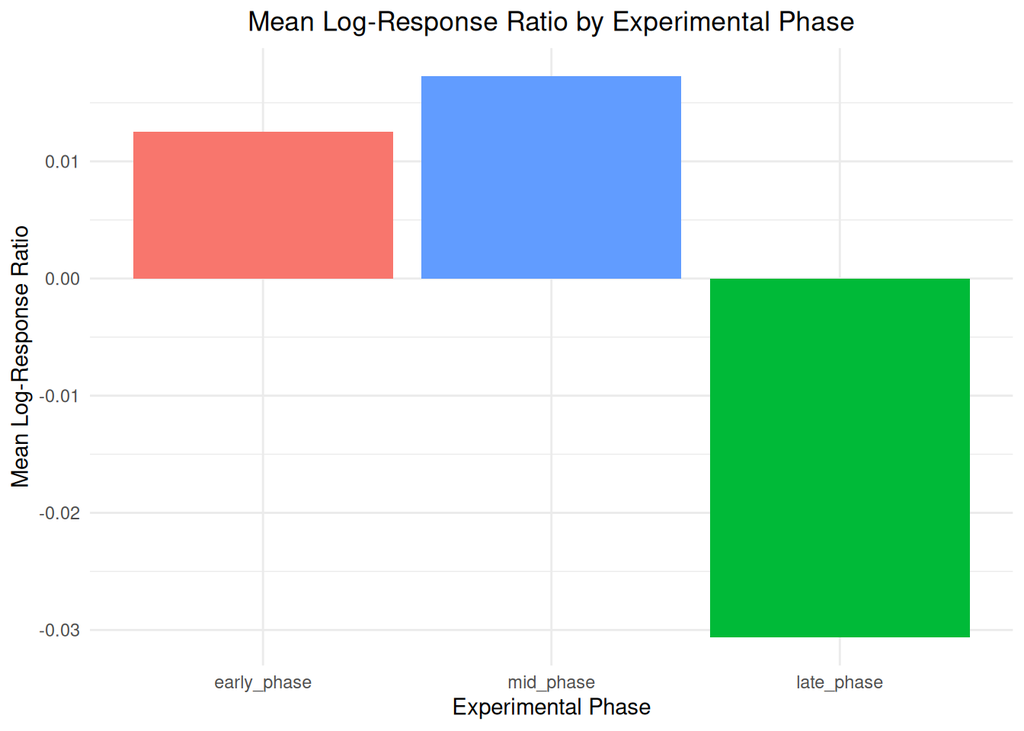

```r
ggplot(phase_aggregate,
       aes(x = phase, y = mean_log_response_ratio, fill = phase)) +
  geom_bar(stat = "identity") +
  labs(title = "Mean Log-Response Ratio by Experimental Phase", x = "Experimental Phase", y = "Mean Log-Response Ratio") +
  scale_x_discrete(limits = c("early_phase", "mid_phase", "late_phase")) +  # X axis value order
  theme_minimal() +
  theme(legend.position = "none",
        # Remove legend
        plot.title = element_text(hjust = 0.5))  # Center the title
```

## 8. Interpretation

1. **What are the data that you are looking at?**  
   *The dataset contains measurements of soil organic carbon (SOC) under both ambient and elevated CO<sub>2</sub> levels across multiple experiments. The variable `n_sample_SOC_ambient` represents the number of observations (sample size) under ambient conditions, while `n_sample_SOC_elevated` indicates the sample size under elevated CO<sub>2</sub> conditions. The variable `time_years` refers to the total number of years each experiment has been conducted. The `log_response_ratio` measures the effect of elevated CO<sub>2</sub> on SOC for each observation, and the `mean_log_response_ratio` aggregates the response across different experimental phases. The experimental phases are categorized as follows: `early_phase` if the experiment has been running for less than three years, `late_phase` if it has been running for more than six years, and `mid_phase` if it has been running for a duration between three and six years.*
2. **What do you expect your analysis to show, what is your hypothesis?**  
   **How should soil organic matter content change under elevated *CO<sub>2</sub>*?**  
   *The hypothesis is that elevated CO<sub>2</sub> levels enhance plant growth, leading to increased biomass production. As more plant residues enter the soil, soil organic carbon (SOC) levels should rise due to greater carbon input.*
3. **Interpret your results after aggregating the data: What do your final numbers mean? Do they support your initial hypothesis? Why so, why not?**  
   *The mean log response ratio indicates whether the soil organic carbon (SOC) levels increased or decreased under elevated CO<sub>2</sub> conditions. A mean log response greater than 0 suggests that SOC increased, while a mean log response less than 0 indicates a decrease in SOC under higher CO<sub>2</sub> levels. In this study, the mean log response ratios were positive during the early phase (0.0125) and mid-phase (0.0173), but negative during the late phase (-0.0306). This finding only partially supports the hypothesis. There was a slight increase in SOC during the first six years of elevated CO<sub>2</sub> levels, which supports the hypothesis. However, this was followed by a decrease in SOC beyond the six-year mark, contradicting the hypothesis. This suggests that elevated CO<sub>2</sub> levels may only lead to a short-term increase in SOC. The original paper offers a possible explanation for this phenomenon: The initial increase in SOC may lead to greater microbial decomposition, which accelerates soil carbon turnover and limits the long-term accumulation of carbon in the soil.*

**Reference:** Kees Jan van Groenigen *et al.,* Faster Decomposition Under Increased Atmospheric CO<sub>2</sub> Limits Soil Carbon Storage. *Science* **344**, 508-509 (2014). DOI: 10.1126/science.1249534